# Homework 3

Author

Yifei Wang

GitHub repository: https://github.com/suyi-afk/stats506/tree/main/hw3

# Problem 1

## Load data

```r
library("haven")

prepare <- function(url, dest) {
  if (!file.exists(dest)) {
    download.file(url, destfile = dest, method = "curl", extra = "-s")
  }
  read_xpt(dest)
}

base_url <- "https://wwwn.cdc.gov/Nchs/Data/Nhanes/Public/2015/DataFiles/"
base_folder <- "./p1/"
if (!dir.exists("p1")) dir.create("p1")
aux_data <- prepare(
  paste0(base_url, "AUX_I.xpt"),
  paste0(base_folder, "AUX_I.xpt")
)
demo_data <- prepare(
  paste0(base_url, "DEMO_I.xpt"),
  paste0(base_folder, "DEMO_I.xpt")
)
```

```r
df <- merge(aux_data, demo_data, by = "SEQN")
dim(df)
```

```
[1] 4582  119
```

After merging, we have 4,582 observations.

## Data Clean Up

```r
df$RIAGENDR <- factor(
  df$RIAGENDR,
  levels = c(1, 2),
  labels = c("Male", "Female")
)

df$DMDCITZN <- factor(
  df$DMDCITZN,
  levels = c(1, 2),
  labels = c("Citizen by birth or naturalization", "Not a citizen of the US")
)

df$DMDHHSZA <- factor(
  df$DMDHHSZA,
  levels = c(0, 1, 2, 3),
  labels = c("0", "1", "2", "3 or more"),
  ordered = TRUE
)

df$INDHHIN2 <- factor(
  df$INDHHIN2,
  levels = c(1, 2, 3, 4, 5, 6, 7, 8, 9, 10, 14, 15),
  labels = c(
    "$ 0 to $ 4,999",
    "$ 5,000 to $ 9,999",
    "$10,000 to $14,999",
    "$15,000 to $19,999",
    "$20,000 to $24,999",
    "$25,000 to $34,999",
    "$35,000 to $44,999",
    "$45,000 to $54,999",
    "$55,000 to $64,999",
    "$65,000 to $74,999",
    "$75,000 to $99,999",
    "$100,000 and Over"
  ),
  ordered = TRUE
)
```

```r
369 / length(df$INDHHIN2)
```

```
[1] 0.08053252
```

`df$INDHHIN2` mixed values with overlapping intervals. The category “Under $20,000” and “$20,000 and Over” do not have a good order compared with other groups. There are total 369 (8%) data in these two categories. We consider to drop these data, since losing 8% of data do not make great harm to modeling later. But remove these data make the order relationship more clear.

```r
df_model <- data.frame(
  Right = df$AUXTWIDR,
  Left = df$AUXTWIDL,
  Gender = df$RIAGENDR,
  Citizenship = df$DMDCITZN,
  Children = c(
    "0" = 0,
    "1" = 1,
    "2" = 2,
    "3 or more" = 3
  )[as.character(df$DMDHHSZA)],
  Income_log = c(
    "$ 0 to $ 4,999" = log(sqrt(2500)),
    "$ 5,000 to $ 9,999" = log(sqrt(5000 * 10000)),
    "$10,000 to $14,999" = log(sqrt(10000 * 15000)),
    "$15,000 to $19,999" = log(sqrt(15000 * 20000)),
    "$20,000 to $24,999" = log(sqrt(20000 * 25000)),
    "$25,000 to $34,999" = log(sqrt(25000 * 35000)),
    "$35,000 to $44,999" = log(sqrt(35000 * 45000)),
    "$45,000 to $54,999" = log(sqrt(45000 * 55000)),
    "$55,000 to $64,999" = log(sqrt(55000 * 65000)),
    "$65,000 to $74,999" = log(sqrt(65000 * 75000)),
    "$75,000 to $99,999" = log(sqrt(75000 * 100000)),
    "$100,000 and Over" = log(sqrt(100000 * 200000))
  )[as.character(df$INDHHIN2)]
)
```

We convert children number and income into continuous variables. The children count has a category “3 or more”, and we treat it as 3 to simplify the model. And for income, we use the midpoints of each interval and apply the log transformation. And since we use midpoint, we have to choose a upper bound for the last interval. We choose 200k for it so it has width 4x the previous interval.

## Fit Models

```r
model_1l <- glm(Left ~ Gender, data = df_model, family = poisson)
model_1r <- glm(Right ~ Gender, data = df_model, family = poisson)
model_2l <- glm(
  Left ~ Gender + Citizenship + Children + Income_log,
  data = df_model, family = poisson
)
model_2r <- glm(
  Right ~ Gender + Citizenship + Children + Income_log,
  data = df_model, family = poisson
)
models <- list(
  "1L" = model_1l, "1R" = model_1r,
  "2L" = model_2l, "2R" = model_2r
)
```

```r
fit_result <- data.frame(
  row.names = names(models),
  SampleSize = sapply(models, nobs),
  Intercept = sapply(models, \(x) unname(exp(coef(x))["(Intercept)"])),
  GenderFemale = sapply(models, \(x) unname(exp(coef(x))["GenderFemale"])),
  NotCitizen = sapply(models, \(x) {
    unname(exp(coef(x))["CitizenshipNot a citizen of the US"])
  }),
  Children = sapply(models, \(x) unname(exp(coef(x))["Children"])),
  Income_log = sapply(models, \(x) unname(exp(coef(x))["Income_log"])),
  PresdoR2 = sapply(models, \(x) 1 - x$deviance / x$null.deviance),
  AIC = sapply(models, \(x) AIC(x))
)
```

```r
library(knitr)
library(kableExtra)

kable(fit_result,
  format = "html",
  digits = 3,
  caption = "Regression Model Comparison",
  align = "c"
) |> kable_styling(
  bootstrap_options = c("striped", "hover", "condensed", "responsive"),
  full_width = FALSE,
  position = "center"
)
```

Regression Model Comparison

|  | SampleSize | Intercept | GenderFemale | NotCitizen | Children | Income_log | PresdoR2 | AIC |
| --- | --- | --- | --- | --- | --- | --- | --- | --- |
| 1L | 4103 | 84.758 | 1.013 | NA | NA | NA | 0.000 | 98685.15 |
| 1R | 4149 | 84.317 | 1.009 | NA | NA | NA | 0.000 | 96618.48 |
| 2L | 3665 | 95.164 | 1.020 | 1.025 | 0.983 | 0.989 | 0.003 | 86662.34 |
| 2R | 3705 | 93.703 | 1.016 | 1.051 | 0.995 | 0.989 | 0.004 | 85044.68 |

```r
summary(model_2l)
```

```
Call:
glm(formula = Left ~ Gender + Citizenship + Children + Income_log,
    family = poisson, data = df_model)

Coefficients:
                                    Estimate Std. Error z value Pr(>|z|)
(Intercept)                         4.555604   0.014579 312.475  < 2e-16 ***
GenderFemale                        0.019700   0.003597   5.477 4.33e-08 ***
CitizenshipNot a citizen of the US  0.024371   0.004633   5.261 1.44e-07 ***
Children                           -0.017168   0.002729  -6.291 3.16e-10 ***
Income_log                         -0.011478   0.001333  -8.610  < 2e-16 ***
---
Signif. codes:  0 '***' 0.001 '**' 0.01 '*' 0.05 '.' 0.1 ' ' 1

(Dispersion parameter for poisson family taken to be 1)

    Null deviance: 64149  on 3664  degrees of freedom
Residual deviance: 63981  on 3660  degrees of freedom
  (917 observations deleted due to missingness)
AIC: 86662

Number of Fisher Scoring iterations: 4
```

```r
est <- summary(model_2l)$coefficients["GenderFemale", "Estimate"]
est
```

```
[1] 0.01970008
```

```r
se <- summary(model_2l)$coefficients["GenderFemale", "Std. Error"]
ci <- est + c(-1, 1) * 1.96 * se
ci
```

```
[1] 0.01264987 0.02675028
```

```r
exp(ci)
```

```
[1] 1.012730 1.027111
```

Since p-value < 0.001, there is a statistically significant difference between females and males. And given IRR = 1.020, females have higher average Tympanometric width in their left ear compared to males. The 95% CI is (1.013, 1.027) which strictly above 1, also confirmed that the statistically significant increase in predicted Tympanometric width for women relative to men.

[output not shown]

# Problem 2 - Sakila

```r
library(DBI)
library(RSQLite)
library(dplyr)
library(microbenchmark)
```

## Load the data

```r
if (!dir.exists("./p2/sakila-sqlite3")) {
  if (!dir.exists("p3")) dir.create("p3")
  system(paste(
    "git clone",
    "https://github.com/bradleygrant/sakila-sqlite3.git",
    "./p2/sakila-sqlite3",
    "-q"
  ))
}
```

## Open the database

```r
con <- dbConnect(RSQLite::SQLite(), "./p2/sakila-sqlite3/sakila_master.db")
```

## Part A

For each store, how many customers does that store have, and what percentage of customers of that store are active in the system?

```r
a1 <- function() {
  customer_table <- dbGetQuery(con, "
    SELECT store_id, customer_id, active
    FROM customer
  ")
  customer_table |>
    group_by(.data$store_id) |>
    summarise(
      total_customers = n(),
      active_percent = mean(.data$active == 1) * 100
    )
}

a1()
```

```
# A tibble: 2 × 3
  store_id total_customers active_percent
     <int>           <int>          <dbl>
1        1             326           97.5
2        2             273           97.4
```

```r
a2 <- function() {
  dbGetQuery(con, "
    SELECT
      store_id,
      COUNT(customer_id) AS total_customers,
      AVG(active) * 100 AS active_percent
    FROM customer
    GROUP BY store_id;
  ")
}

a2()
```

```
  store_id total_customers active_percent
1        1             326       97.54601
2        2             273       97.43590
```

```r
microbenchmark(
  a1(),
  a2(),
  times = 100
)
```

```
Unit: microseconds
 expr    min      lq     mean median      uq    max neval
 a1() 1511.3 1625.30 1806.929 1705.5 1828.70 4441.7   100
 a2()  187.0  225.15  280.188  279.4  307.95  855.2   100
```

Both methods report that there are 2 stores: store 1 has 326 customers, 97.5% are active; while store 2 has 273 customers, 97.4% are active.

## Part B

Generate a table identifying the names and country of each staff member.

```r
b1 <- function() {
  staff_table <- dbGetQuery(con,
    "SELECT first_name, last_name, address_id FROM staff"
  )
  address_table <- dbGetQuery(con,
    "SELECT address_id, city_id FROM address"
  )
  city_table <- dbGetQuery(con, "SELECT city_id, country_id FROM city")
  country_table <- dbGetQuery(con, "SELECT country_id, country FROM country")

  staff_table |>
    inner_join(address_table, by = c("address_id" = "address_id")) |>
    inner_join(city_table, by = c("city_id" = "city_id")) |>
    inner_join(country_table, by = c("country_id" = "country_id")) |>
    select(.data$first_name, .data$last_name, .data$country)
}

b1()
```

```
  first_name last_name   country
1       Mike   Hillyer    Canada
2        Jon  Stephens Australia
```

```r
b2 <- function() {
  dbGetQuery(con, "
    SELECT first_name, last_name, country
    FROM staff s
      JOIN address a ON s.address_id = a.address_id
      JOIN city c ON a.city_id = c.city_id
      JOIN country o ON c.country_id = o.country_id
  ")
}

b2()
```

```
  first_name last_name   country
1       Mike   Hillyer    Canada
2        Jon  Stephens Australia
```

```r
microbenchmark(
  b1(),
  b2(),
  times = 100
)
```

```
Unit: microseconds
 expr    min      lq     mean  median      uq     max neval
 b1() 8305.2 8817.95 9335.469 9092.20 9472.65 13010.5   100
 b2()  128.5  163.30  224.855  228.65  255.60  1045.0   100
```

Both methods retrieved two staff members. Mike Hillyer from Canada and Jon Stephens from Australia.

This time, the second method is 40x faster than the first one.

## Part C

Identify the name(s) of the film(s) which was/were rented for the highest dollar value.

```r
c1 <- function() {
  payment_table <- dbGetQuery(con, "
    SELECT rental_id, amount
    FROM payment
  ")
  rental_table <- dbGetQuery(con, "
    SELECT rental_id, inventory_id
    FROM rental
  ")
  inventory_table <- dbGetQuery(con, "
    SELECT inventory_id, film_id
    FROM inventory
  ")
  film_table <- dbGetQuery(con, "
    SELECT film_id, title
    FROM film
  ")

  payment_table |>
    inner_join(rental_table, by = c("rental_id" = "rental_id")) |>
    inner_join(inventory_table, by = c("inventory_id" = "inventory_id")) |>
    inner_join(film_table, by = c("film_id" = "film_id")) |>
    group_by(.data$title) |>
    summarise(total_amount = sum(.data$amount)) |>
    arrange(desc(.data$total_amount)) |>
    head(1)
}

c1()
```

```
# A tibble: 1 × 2
  title            total_amount
  <chr>                   <dbl>
1 TELEGRAPH VOYAGE         232.
```

```r
c2 <- function() {
  dbGetQuery(con, "
    SELECT f.title, sum(amount) total_amount
    FROM payment p
      JOIN rental r ON p.rental_id = r.rental_id
      JOIN inventory i ON r.inventory_id = i.inventory_id
      JOIN film f ON i.film_id = f.film_id
    GROUP BY f.film_id
    ORDER BY sum(p.amount) DESC
    LIMIT 1;
  ")
}

c2()
```

```
             title total_amount
1 TELEGRAPH VOYAGE       231.73
```

```r
microbenchmark(
  c1(),
  c2(),
  times = 100
)
```

```
Unit: milliseconds
 expr     min       lq     mean   median      uq      max neval
 c1() 23.8071 24.86405 27.11021 26.06055 27.1754 102.3881   100
 c2() 27.3242 28.67285 29.83237 29.43850 30.3024  42.7475   100
```

Both methods report the film “TELEGRAPH VOYAGE” has highest rented income, which is $231.73.

However, for this case, the first method is slightly faster than the second one.

# Problem 3 - Australian Records

## Load the data

```r
if (!file.exists("./p3/au-500.csv")) {
  if (!dir.exists("p3")) dir.create("p3")
  au500_url = "https://www.briandunning.com/sample-data/au-500.zip"
  f <- tempfile(fileext = ".zip")
  download.file(au500_url, f, method = "curl", extra = "-s")
  unzip(f, files = "au-500.csv", exdir = "./p3")
}
```

```r
df <- read.csv("./p3/au-500.csv")
```

# Part A

What percentage of the websites are .com’s (as opposed to .net, .com.au, etc)?

```r
table(sub(".*\\.", "", df$web))
```

```
 au
500
```

None website is ended with `.com`. All websites in the dataset ends with `.au`.

## Part B

What is the most common domain name amongst the email addresses? (In the email “statistics@umich.edu”, “umich.edu” is the domain name.)

```r
counts <- table(sub(".*@", "", df$email))
counts[order(counts, decreasing = TRUE)][1:5]
```

```
 hotmail.com    gmail.com    yahoo.com  agar.net.au agney.net.au
         114          102           84            1            1
```

The most common domain name amongst the email address is `hotmail.com`.

## Part C

What proportion of company names contain a non-alphabetic character, excluding commas and whitespace. (E.g. “Jane Doe, LLC” would not contain an eligible non-alphabetic character; “Plumber 247” would.) What about if you also exclude ampersands (“&”)?

```r
mean(grepl("[^\\p{l},\\s]", df$company_name, perl = TRUE))
```

```
[1] 0.09
```

```r
mean(grepl("[^\\p{l},\\s&]", df$company_name, perl = TRUE))
```

```
[1] 0.008
```

There are 9% company names containing a non-alphabetic character, excluding commas and whitespace. And the proportion decrease to 0.8% if we further exclude ampersands.

## Part D

In Australia, phone have 10 digits - but unlike in the US where we write all numbers as “123-456-7890”, they write land lines and cell phones differently. - Landlines: 12-3456-7890 - Cell phones: 1234-567-890

There are two different phones listed for each record. Make all phone numbers written like cell phones. Show it works by printing the first 10 phone numbers of each column.

```r
format_cell_phone <- function(x) {
  sub(
    "(\\d\\d\\d\\d)(\\d\\d\\d)(\\d\\d\\d)",
    "\\1-\\2-\\3",
    gsub("-", "", x)
  )
}
c(format_cell_phone(df$phone1)[1:10], format_cell_phone(df$phone2)[1:10])
```

```
 [1] "0381-749-123" "0799-973-366" "0855-589-019" "0260-444-682" "0214-556-085"
 [6] "0878-681-355" "0865-228-931" "0252-269-402" "0731-849-989" "0868-904-661"
[11] "0458-665-290" "0497-622-620" "0427-885-282" "0443-795-912" "0453-666-885"
[16] "0451-966-921" "0427-991-688" "0415-961-606" "0411-732-965" "0461-862-457"
```

## Part E

Produce a histogram of the log of the apartment numbers for all addresses. (You may assume any number at the end of the an address is an apartment number.)

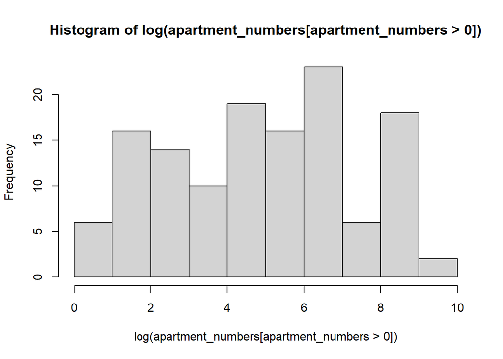

```r
apartment_numbers <- na.omit(as.numeric(sub(".*?(\\d*)$", "\\1", df$address)))
hist(log(apartment_numbers[apartment_numbers > 0]))
```

## Part F

Benford’s law is an observation about the distribution of the leading digit of real numerical data. Examine whether the apartment numbers appear to follow Benford’s law. Do you think the apartment numbers would pass as real data?

```r
table(as.numeric(sub("^(.).*", "\\1", as.character(apartment_numbers))))
```

```
 1  2  3  4  5  6  7  8  9
12 19 16 13 14 18  8 11 19
```

As the counts show, the data does not follow Benford’s law. The digit 1 should appear most often, but digits 2 and 9 appear more frequently. Therefore, I do not think these apartment numbers would pass as real data based on Benford’s law.